# project3

### #2 Total Carbon Emissions by (small) Region

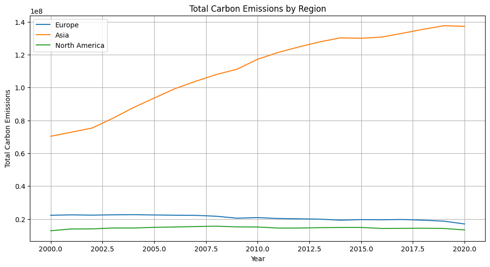

```python
europe = ['Germany', 'France', 'Italy', 'Spain', 'United Kingdom', 'Netherlands']
asia = ['China', 'India', 'Japan', 'South Korea']
north_america = ['United States', 'Canada', 'Mexico']
regions = {'Europe': europe, 'Asia': asia, 'North America': north_america}
region_emissions = {}
for region, countries in regions.items():
    region_emissions[region] = df[df['Area'].isin(countries)].iloc[:, 4:].sum(axis=0)
plt.figure(figsize=(12, 6))
for region, emissions in region_emissions.items():
    plt.plot(emissions.index, emissions.values, label=region)
plt.title('Total Carbon Emissions by Region')
plt.xlabel('Year')
plt.ylabel('Total Carbon Emissions')
plt.legend()
plt.grid(True)
plt.show()
```

### #3 Total Carbon Emissions in 2020

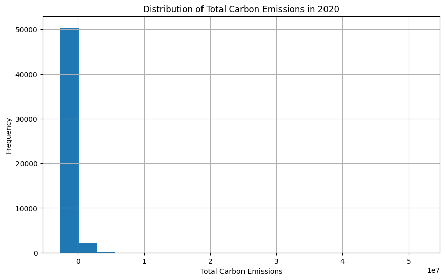

```python
plt.figure(figsize=(10, 6))
plt.hist(df[2020], bins=20)
plt.title(f'Distribution of Total Carbon Emissions in 2020')
plt.xlabel('Total Carbon Emissions')
plt.ylabel('Frequency')
plt.grid(True)
plt.show()
```

The plot depicts a histogram with the horizontal axis representing the total carbon emissions, and the vertical axis indicating the frequency of occurrences of carbon emission values within specific bins.

### #4 Distribution of Total Carbon Emissions in 2009 vs 2020 for Syria

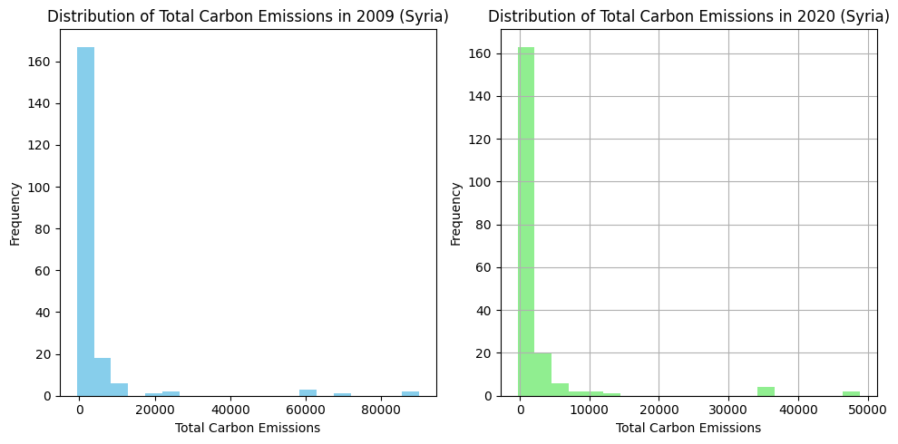

```python
syria_data = df[df['Area'] == 'Syrian Arab Republic'][[2009, 2020]]
plt.figure(figsize=(10, 5))
plt.subplot(1, 2, 1)
plt.hist(syria_data[2009], bins=20, color='skyblue')
plt.title('Distribution of Total Carbon Emissions in 2009 (Syria)')
plt.xlabel('Total Carbon Emissions')
plt.ylabel('Frequency')

plt.subplot(1, 2, 2)
plt.hist(syria_data[2020], bins=20, color='lightgreen')
plt.title('Distribution of Total Carbon Emissions in 2020 (Syria)')
plt.xlabel('Total Carbon Emissions')
plt.ylabel('Frequency')
plt.grid(True)

plt.tight_layout()  # no overlap
plt.show()
```

This code generates two histograms to illustrate the distribution of total carbon emissions in Syria for the years 2009 and 2020.